# The Best Coffee-Producing Company in The World is…

SARAH BEASLEY

February 17th, 2022

```r
# Load any R Packages you may need
library(tidyverse)
library(janitor)
library(plyr)
library(ggthemes)
library(viridis)
library(gganimate)
library(gifski)
library(ggthemr)
```

# The Importance of Beans

College students live and function off of their caffeine intake. Whether it’s to meet deadlines or to stay awake in an 8 AM lecture, students across the globe consume caffeine at a high, frequent rate. In today’s day and age, the most generic and wide-spread form of caffeine is *coffee*. With many different types of coffee and styles of making a coffee-based drink, there’s a type for everyone, even if they don’t like the original taste.

Most of these distinct tastes come from the type and roast of the coffee beans produced. The place where the beans were grown and harvested also have a distinct effect on the coffee’s taste. The coffee plant is native to Ethiopia, but has since been harvested in many other countries in places with high humidity and plenty of water.

There are two species of coffee beans: Arabica and Robusta. Arabica beans tend to be more light and sweet-tasting than Robusta beans, which are usually more dense and bitter. Both species can be cultivated, but Arabica beans are more difficult to grow, and therefore more expensive than Robusta beans.

This coffee dataset comes from the Coffee Quality Institute and Database, which rates the quality of several different factors of coffee from around the globe, while also taking information on the production. In this study, we will mainly focus on the coffee’s country of origin, and a few different rating factors from the dataset.

In general, we can assume that the best coffee will come from the countries that produce the most coffee, since they would be well-renowned in making it due to their mass production. When looking at the data, the top four countries in coffee production are Mexico, Colombia, Guatemala, and Brazil, in that order. These top four countries all produce Arabica beans rather than Robusta beans.

How do these mass-producing countries compare to the original producer of coffee beans when regarding the overall rating and the species of bean?

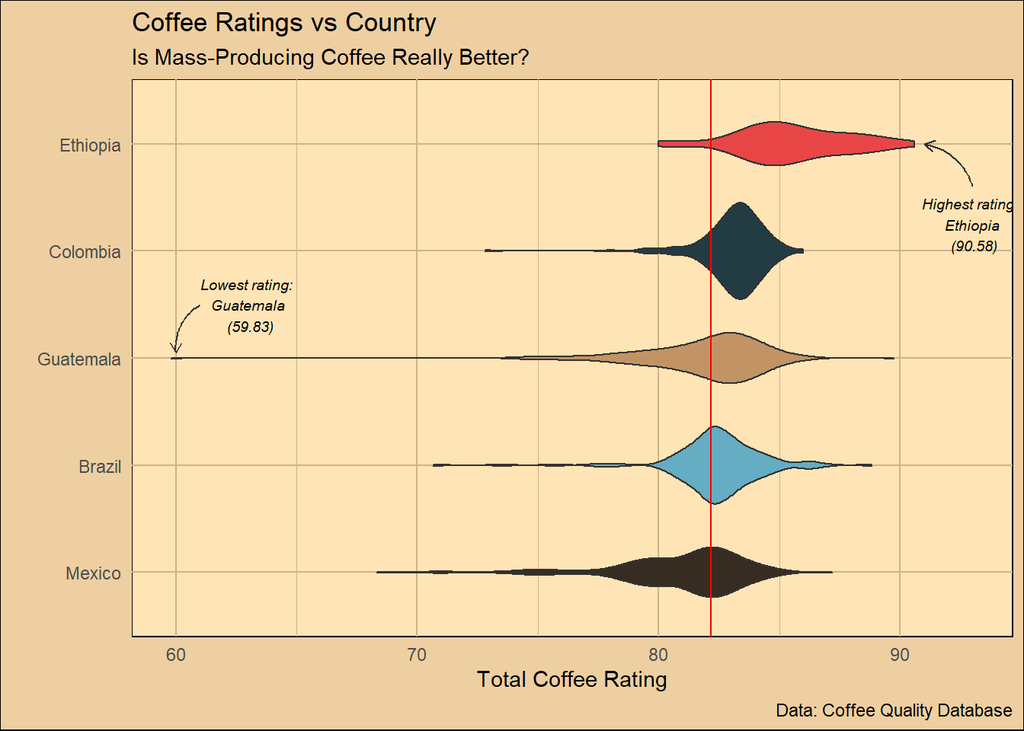

```r
ggthemr("fresh")
ggplot(top_five_coffee, aes(x = fct_reorder(country_of_origin, total_cup_points), y = total_cup_points)) +
  geom_violin(aes(fill = country_of_origin)) +
  geom_hline(aes(yintercept = mean_coffee), color = "red") +
  theme_minimal() +
    theme(legend.position = "none", panel.background = element_rect(fill = "moccasin"),  panel.grid = element_line(color = "navajowhite3"), plot.background = element_rect(fill = "navajowhite2")) +
    labs(x = "", y = "Total Coffee Rating", title = "Coffee Ratings vs Country", subtitle = "Is Mass-Producing Coffee Really Better?", caption = "Data: Coffee Quality Database") +
    coord_flip()  +
  annotate("text", x = 3.5, y = 63, fontface = "italic",
           size = 2.5, color = "black",
           label = "Lowest rating: \n Guatemala \n (59.83)") +
  geom_curve(x = 3.5, xend = 3.05, y = 61, yend = 60,
             arrow = arrow(length = unit(0.08, "inch")), size = 0.5,
             color = "gray20", curvature = 0.3) +
  annotate("text", x = 4.25, y = 93, fontface = "italic",
           size = 2.5, color = "black",
           label = "Highest rating: \n Ethiopia \n (90.58)") +
  geom_curve(x = 4.6, xend = 5, y = 93, yend = 91,
             arrow = arrow(length = unit(0.08, "inch")), size = 0.5,
             color = "gray20", curvature = 0.3)
```

This graphic displays the top four countries with the most amount of coffee produced, along with Ethiopia at the top of the graph. Ethiopia was put in as a comparison to show how the original climate coffee plants were grown in compared to it’s competition. A violin plot was chosen to display the density of each country’s coffee ratings. The x-axis displays the total rating of each individual coffee, to display how the mass-production in the countries affects it’s quality. The colors of the data also represent each individual country, to highlight the differences between the five and to allow readers to understand the display easier. The two arrows point to the highest and the lowest score within the data to show viewers exactly where the maximum and minimum scores are for further discussion. The red line demonstrates the mean overall rating of all of the coffee made and rated in these five countries.

The mean line tells us a few things. Firstly, both Ethiopia and Columbia’s ratings are majority above the line. This indicates that, generally, their coffee is better when comparing to the other three countries. Secondly, Guatemala and Brazil’s ratings are around that mean line, and generally dispersed evenly around it. This means that their coffee can be compared either to that of the higher-end quality or the lower-end quality. Lastly, Mexico’s ratings tend to fall below the mean line. Since we also know that this is the highest-producing country, it is likely that mass-production has had an effect on the quality of the coffee produced. This also applied to the other four countries, just on a smaller scale.

From this data, we can conclude that even though some countries are the top-producers of coffee, quantity doesn’t always mean quality.

Now, since we have shown that Ethiopia has some of the top-tasting coffee in the world, let’s dive into *why* this coffee is so good.

## Weilding Two Senses

The METAD PLC coffee farm has produced many of the best coffees in the world (according to the overall points). Many of these batches of rich, Arabica coffee beans were made in 2015. But what makes this coffee so good?

Flavor is a combination of both taste and smell. Our gustatory and olfactory systems work together to create either a horrible, or beautiful harmony of flavors. Therefore, coffee’s aroma also adds to it’s flavorful and unique taste.

Let’s look at how the aroma score of the coffee affects the flavor score in the coffee data from Ethiopia.

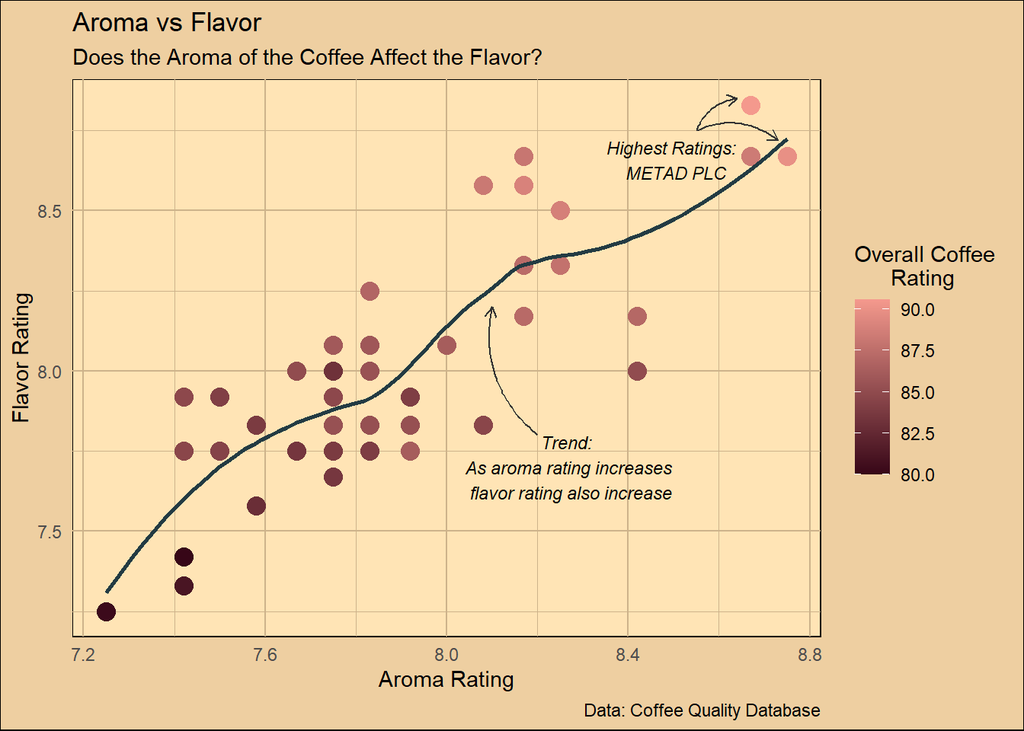

```r
ggplot(ethiopia_coffee, aes(x = aroma, y = flavor)) +
  geom_point(aes(color = total_cup_points), size = 4) +
  geom_smooth(se = FALSE) +
  scale_color_gradientn(colors = coffee_colors) +
  theme_minimal() +
  theme(legend.position = "right", panel.background = element_rect(fill = "moccasin"),  panel.grid = element_line(color = "navajowhite3"), plot.background = element_rect(fill = "navajowhite2")) +
    labs(x = "Aroma Rating", y = "Flavor Rating", title = "Aroma vs Flavor", subtitle = "Does the Aroma of the Coffee Affect the Flavor?", caption = "Data: Coffee Quality Database", color = "Overall Coffee \n      Rating") +
  annotate("text", x = 8.27, y = 7.7, fontface = "italic",
           size = 3, color = "black",
           label = "Trend: \n As aroma rating increases \n flavor rating also increase") +
  geom_curve(x = 8.2, xend = 8.1, y = 7.8, yend = 8.2,
             arrow = arrow(length = unit(0.08, "inch")), size = 0.5,
             color = "gray20", curvature = -0.3) +
  geom_curve(x = 8.55, xend = 8.73, y = 8.75, yend = 8.72,
             arrow = arrow(length = unit(0.08, "inch")), size = 0.5,
             color = "gray20", curvature = -0.3) +
   geom_curve(x = 8.55, xend = 8.64, y = 8.75, yend = 8.85,
             arrow = arrow(length = unit(0.08, "inch")), size = 0.5,
             color = "gray20", curvature = -0.3) +
   annotate("text", x = 8.5, y = 8.66, fontface = "italic",
           size = 3, color = "black",
           label = "Highest Ratings: \n METAD PLC")
```

This graph displays the coffee aroma ratings versus the flavor ratings.The x-axis contains the aroma rating, while the y-axis displays the flavor ratings. A scatterplot was used since there are two numerical variables and we are testing for a relation between the two. The size of the points were increased to show the data points easier so viewers can comprehend the relationship. A trend-line was inputted to display the correlation between the two variables.

The trend is clear: *as aroma rating increases, so does flavor rating*.

Once again, METAD PLC is at the top of the list in both flavor *and* aroma, having the top two data points. The flavor and aroma are high contributors to the overall score of coffee, and are likely to be the most important to everyday coffee drinkers. The better the flavor and aroma, the more enjoyable a drink is, especially one like coffee.

### Conclusions and Further Queries

Is METAD PLC the best coffee producer? According to this data, yes, they are. With the highest overall rating and the top ratings in both flavor and taste, it seems that their coffee would be the most enjoyable. One must remember that the two coffee batches were made almost 7 years ago in 2015, and has since been compared to coffees made in 2018. However, there is still the need to update this dataset with newer coffees to see if there is anything that can top this Ethiopian coffee farm. Since the farms can undergo many changes, such as weather patterns, a change in ownership, or a pandemic, keeping data updated is important.